# Recommendation System

Murilo Miranda

2/21/2020

```r
library(RMySQL)
library(ggpubr)
library(tidyverse)
```

```r
library(stringr)
library(lubridate)
library(recommenderlab)
library(arules)
library(arulesViz)
library(cluster)
library(factoextra)
library(knitr)
```

We want to build a **recommendation system** to increase cross-selling in our website. Our goal is to show customers who have added a product to their basket another product they’re likely to want. Because of the nature of our data, the best way to do that is by using a method called **Market Basket Analysis**.

The first step is the **data quality** assessment: we need to make sure that we can trust the data that we’re using. Make sure the information across our datasets (*line_item*, *orders* and *products*) is consistent, and get rid of anything too strange or to believe.

Then, we will have to build a **transactional dataset**: a table with one row per order and one column per product bought -meaning that the table has as many columns as the biggest order, with lots of NAs.

Finally, we will use the **apriori algorithm** to create if-then rule with our products: “if a customer buys product A, then it’s likely that they’ll buy product B”. Focus on optimizing the model: it will be deployed into production by our engineering team.

### Read data from mySQL

```r
mydb <-  dbConnect(MySQL(), user = 'root', password = db_password,
                 dbname = 'imarket_sql', host = '127.0.0.1', port = 3306)
rm(db_password)
```

#### import line_item table

```r
rs <- dbSendQuery(mydb, "select * from line_item")
line_item <-  fetch(rs, n = -1)
dbClearResult(rs)
```

#### import orders table

```r
rs <- dbSendQuery(mydb, "select * from orders")
orders <-  fetch(rs, n = -1)
dbClearResult(rs)
```

#### import products table

```r
rs <- dbSendQuery(mydb, "select * from products")
products <-  fetch(rs, n = -1)
dbClearResult(rs)
on.exit(dbDisconnect(mydb))
```

## Data Quality

1. Check that all **orders** in *line_item* are present in our *orders* dataset. Exclude from *line_item* any rows that do not meet that condition.

```r
line_item <- line_item %>% mutate(date = ymd_hms(date), unit_price = as.numeric(gsub(",", ".", unit_price)))

orders <- orders %>% mutate(created_date = ymd_hms(created_date), total_paid = as.numeric(gsub(",", ".", total_paid)))

products <- products %>% mutate(price = as.numeric(as.character(price)))
#mutate(price = str_replace(price, "90{2,}.+", "9")) %>%

line_item_clean <- line_item %>% inner_join(orders, by = "id_order")
```

2. Exclude from *line_item* any rows from orders that are not **“Completed”**.

```r
line_item_clean <- line_item_clean %>% filter(state == "Completed") %>% select(-state, -product_id)
```

3. Check that all **products** in *line_item* are present in the *products* dataset. Exclude from *line_item* any rows that do not meet that condition.

```r
line_item_clean <- line_item_clean %>% filter(sku %in% products$sku)
```

4. Explore the relationship between **prices** in *line_item* and *order*.

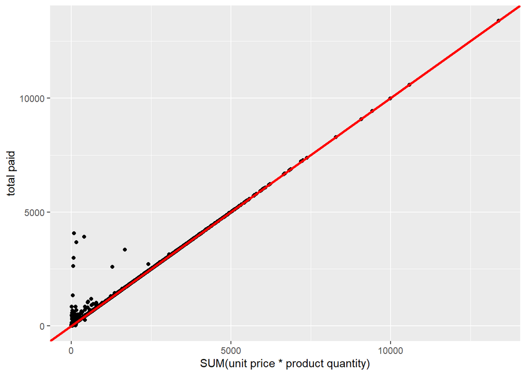

```r
values_paid <- line_item_clean %>% group_by(id_order) %>%
  summarise(total_estimated = sum(unit_price*product_quantity), total_paid = mean(total_paid))

values_paid %>%
  ggplot(aes(x = total_estimated, y = total_paid)) +
  geom_point() +
  geom_abline(colour = 'red', size = 1.1) +
  labs(
    x = "SUM(unit price * product quantity)",
    y = "total paid"
  )
```

1. Do the prices of the orders and the sum of the prices of each item in the order match? If not, can you make some assumptions that explain the differences?

> **No, some orders had more than one product and probably the total paid includes shipping and other taxes.**
2. Exclude from *line_items* the rows with differences that you cannot explain.

```r
values_paid <- values_paid %>% filter(abs(total_estimated - total_paid) < total_paid*0.50)

line_item_clean <- line_item_clean %>% filter(id_order %in% values_paid$id_order)
rm(values_paid)
```

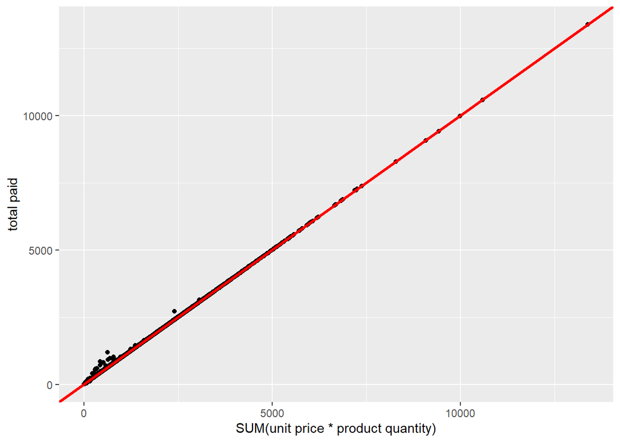

5. Explore the relationship between **prices** in *line_item* and *product*:

```r
line_item_clean <- line_item_clean %>% inner_join(products, by = "sku")
```

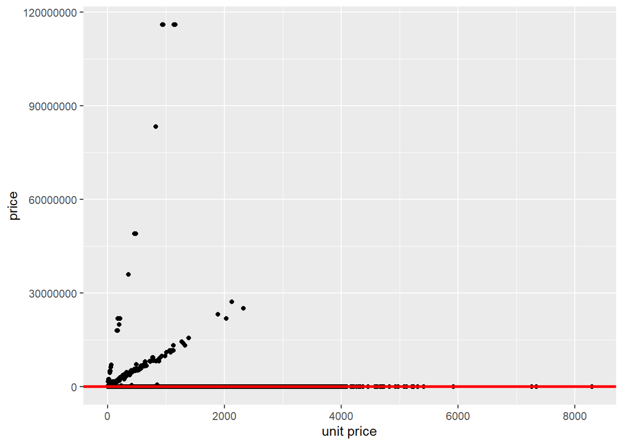

```r
line_item_clean %>% ggplot(aes(unit_price, price)) +
  geom_point() +
  geom_abline(colour = 'red', size = 1.1) +
  labs(
    x = "unit price",
    y = "price"
  )
```

1. Do the prices of the items sold and the product prices match? If not, can you make some assumptions that explain the differences?

> **No, kmeans algorithm identified four groups. Some of these groups were divided into subgroups. Groups/Subgroups were transformed by x-values**

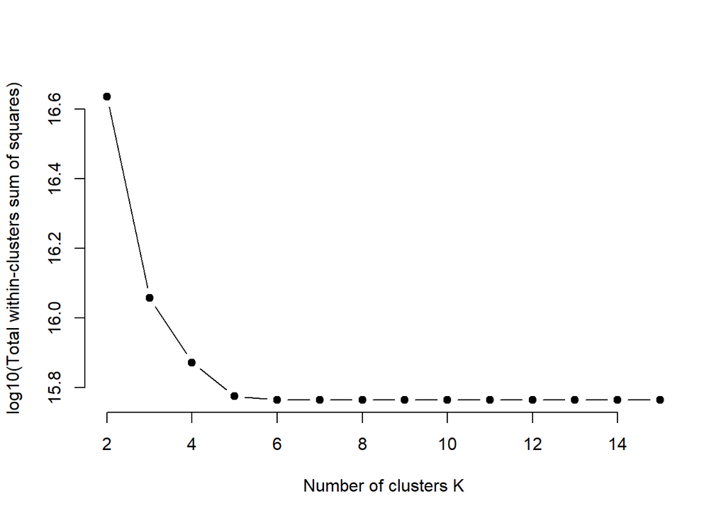

```r
set.seed(1605)

# function to compute total within-cluster sum of square
wss <- function(k) {
  kmeans(line_item_clean[, c("price", "unit_price")], k, nstart = 10 )$tot.withinss
}

# Compute and plot wss for k = 2 to k = 15
k.values <- 2:15

# extract wss for 2-15 clusters
wss_values <- map_dbl(k.values, wss)

plot(k.values, log10(wss_values),
       type="b", pch = 19, frame = FALSE,
       xlab="Number of clusters K",
       ylab="log10(Total within-clusters sum of squares)")
```

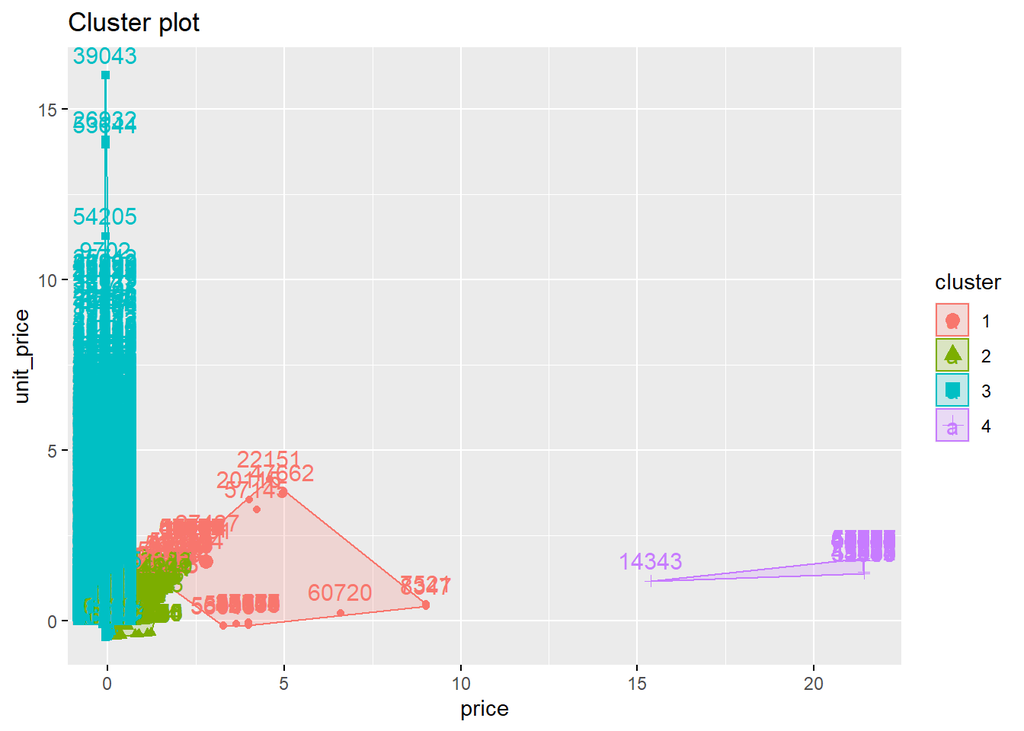

```r
k4 <- kmeans(line_item_clean[, c("price", "unit_price")], centers = 4, nstart = 10)
fviz_cluster(k4, data = line_item_clean[, c("price", "unit_price")])
```

##### Group 1

```r
line_item_group1 <- line_item_clean %>% filter(k4$cluster == 1)

g_before <- line_item_group1 %>% ggplot(aes(unit_price, price)) +
  geom_point() +
  geom_abline(colour = 'red', size = 1.1) +
  labs(
    x = "unit price",
    y = "price"
  )
```

###### Group 1a

```r
line_item_group1a <- line_item_group1 %>% filter(price/unit_price > 30000)
```

```r
line_item_group1a %>% select(unit_price, price) %>% summary()
```

```
##    unit_price      price
##  Min.   :160   Min.   :17998992
##  1st Qu.:208   1st Qu.:21900032
##  Median :219   Median :21900032
##  Mean   :237   Mean   :24344277
##  3rd Qu.:219   3rd Qu.:21900032
##  Max.   :489   Max.   :49033072
```

```r
line_item_group1a <- line_item_group1a %>% mutate(price = price/100000)
```

###### Group 1b

```r
line_item_group1b <- line_item_group1 %>% filter(price/unit_price < 30000)
```

```r
line_item_group1b %>% select(unit_price, price) %>% summary()
```

```
##    unit_price       price
##  Min.   : 768   Min.   : 9188385
##  1st Qu.:1329   1st Qu.:13290011
##  Median :1329   Median :13290011
##  Mean   :1310   Mean   :13365832
##  3rd Qu.:1329   3rd Qu.:13290011
##  Max.   :2330   Max.   :27138385
```

```r
line_item_group1b <- line_item_group1b %>% mutate(price = price/10000)
```

```r
line_item_group1 <- line_item_group1a %>% bind_rows(line_item_group1b)

g_after <- line_item_group1 %>% ggplot(aes(unit_price, price)) +
  geom_point() +
  geom_abline(colour = 'red', size = 1.1) +
  labs(
    x = "unit price",
    y = "price"
  )

rm(line_item_group1a, line_item_group1b)
```

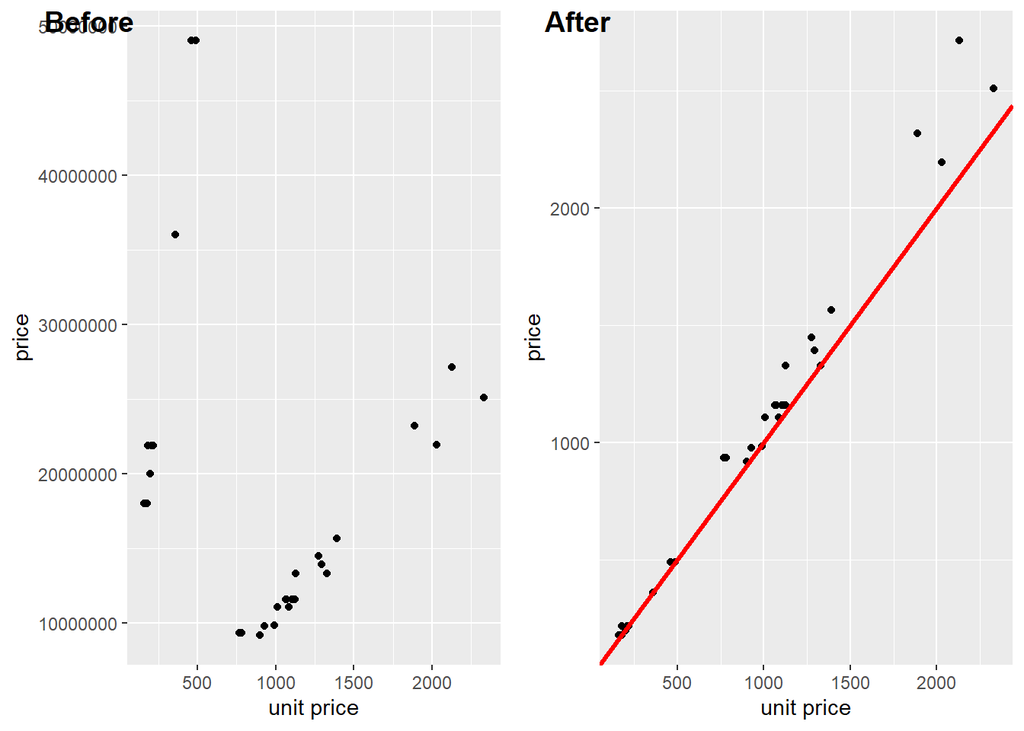

```r
ggarrange(g_before, g_after, labels = c("Before", "After"), ncol = 2, nrow = 1)
```

##### Group 2

```r
line_item_group2 <- line_item_clean %>% filter(k4$cluster == 2)

g_before <- line_item_group2 %>% ggplot(aes(unit_price, price)) +
  geom_point() +
  geom_abline(colour = 'red', size = 1.1) +
  labs(
    x = "unit price",
    y = "price"
  )
```

###### Group 2a

```r
line_item_group2a <- line_item_group2 %>% filter(price/unit_price > 20000)
```

```r
line_item_group2a %>% select(unit_price, price) %>% summary()
```

```
##    unit_price        price
##  Min.   : 7.99   Min.   :1728001
##  1st Qu.:14.23   1st Qu.:1728001
##  Median :20.99   Median :2499013
##  Mean   :25.51   Mean   :2888755
##  3rd Qu.:24.99   3rd Qu.:2499013
##  Max.   :69.99   Max.   :6999003
```

```r
line_item_group2a <- line_item_group2a %>% mutate(price = price/100000)
```

###### Group 2b

```r
line_item_group2b <- line_item_group2 %>% filter(price/unit_price < 20000)
```

```r
line_item_group2b %>% select(unit_price, price) %>% summary()
```

```
##    unit_price      price
##  Min.   : 93   Min.   :1499892
##  1st Qu.:135   1st Qu.:1639792
##  Median :176   Median :1990002
##  Mean   :254   Mean   :2872277
##  3rd Qu.:312   3rd Qu.:3799592
##  Max.   :879   Max.   :8929696
```

```r
line_item_group2b <- line_item_group2b %>% mutate(price = price/10000)
```

```r
line_item_group2 <- line_item_group2a %>% bind_rows(line_item_group2b)

g_after <- line_item_group2 %>% ggplot(aes(unit_price, price)) +
  geom_point() +
  geom_abline(colour = 'red', size = 1.1) +
  labs(
    x = "unit price",
    y = "price"
  )

rm(line_item_group2a, line_item_group2b)
```

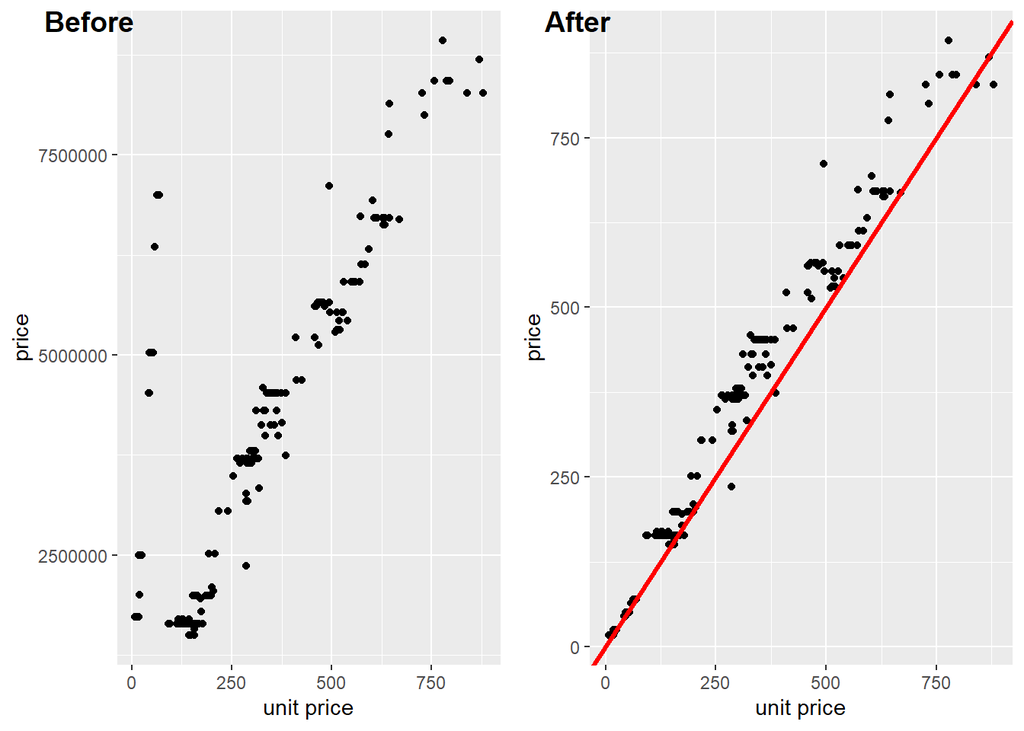

```r
ggarrange(g_before, g_after, labels = c("Before", "After"), ncol = 2, nrow = 1)
```

##### Group 3

```r
line_item_group3 <- line_item_clean %>% filter(k4$cluster == 3)

g_before <- line_item_group3 %>% ggplot(aes(unit_price, price)) +
  geom_point() +
  geom_abline(colour = 'red', size = 1.1) +
  labs(
    x = "unit price",
    y = "price"
  )
```

```r
set.seed(1605)
k2 <- kmeans(line_item_group3[, c("price", "unit_price")], centers = 2, nstart = 10)
```

###### Group 3a

```r
line_item_group3a <- line_item_group3 %>% filter(k2$cluster == 1)
```

There two subgroups: (1) unit price higher than 1000 and price smaller than 7000 (group3aSmall) and (2) unit price smaller than 1000 and price higher than 7000 (group3aHigh)

```r
line_item_group3aSmall <- line_item_group3a %>% filter((price-5000)/unit_price < 50)
```

The group3aSmall was kept.

```r
line_item_group3aHigh <- line_item_group3a %>% filter((price-5000)/unit_price >= 50)
```

The group3aHigh also has two subgroup: (1) ratio price and unit_price higher than 4000 (higher) and (2) ratio price and unit_price smaller than 4000 (smaller).

```r
line_item_higher <- line_item_group3aHigh %>% filter(price/unit_price > 4000)
```

```r
line_item_higher %>% select(unit_price, price) %>% summary()
```

```
##    unit_price        price
##  Min.   : 5.22   Min.   : 57802
##  1st Qu.:15.68   1st Qu.:199892
##  Median :19.99   Median :199892
##  Mean   :20.23   Mean   :213539
##  3rd Qu.:19.99   3rd Qu.:299003
##  Max.   :34.99   Max.   :350005
```

```r
line_item_higher <- line_item_higher %>% mutate(price = price/10000)
```

```r
line_item_smaller <- line_item_group3aHigh %>% filter(price/unit_price < 4000)
```

```r
line_item_smaller %>% select(unit_price, price) %>% summary()
```

```
##    unit_price         price
##  Min.   :  6.16   Min.   :  8257
##  1st Qu.:  7.99   1st Qu.:  9082
##  Median : 19.99   Median : 29274
##  Mean   : 29.88   Mean   : 36736
##  3rd Qu.: 42.99   3rd Qu.: 54329
##  Max.   :242.99   Max.   :292958
```

```r
line_item_smaller <- line_item_smaller %>% mutate(price = price/1000)
```

```r
line_item_group3aHigh <- line_item_higher %>% bind_rows(line_item_smaller)
line_item_group3a <- line_item_group3aSmall %>% bind_rows(line_item_group3aHigh)

rm(line_item_higher, line_item_smaller, line_item_group3aSmall, line_item_group3aHigh)
```

###### Group 3b

```r
line_item_group3b <- line_item_group3 %>% filter(k2$cluster == 2)
```

There two subgroups: (1) unit price smaller than 400 (group3bSmall) and (2) higher than 400 (group3bHigh)

```r
line_item_group3bSmall <- line_item_group3b %>% filter(unit_price < 400)
```

The group3bSmall was divided by 10000.

```r
line_item_group3bSmall %>% select(unit_price, price) %>% summary()
```

```
##    unit_price        price
##  Min.   : 33.7   Min.   : 399905
##  1st Qu.: 60.0   1st Qu.: 599918
##  Median : 65.3   Median : 799895
##  Mean   : 72.0   Mean   : 799382
##  3rd Qu.: 87.0   3rd Qu.: 999799
##  Max.   :136.9   Max.   :1299891
```

```r
line_item_group3bSmall <- line_item_group3bSmall %>% mutate(price = price/10000)
```

```r
line_item_group3bHigh <- line_item_group3b %>% filter(unit_price > 400)
```

The group3bHigh was divided by 1000.

```r
line_item_group3bHigh %>% select(unit_price, price) %>% summary()
```

```
##    unit_price      price
##  Min.   :412   Min.   :432811
##  1st Qu.:413   1st Qu.:432811
##  Median :413   Median :432811
##  Mean   :467   Mean   :462922
##  3rd Qu.:413   3rd Qu.:432811
##  Max.   :848   Max.   :673702
```

```r
line_item_group3bHigh <- line_item_group3bHigh %>% mutate(price = price/1000)
```

```r
line_item_group3b <- line_item_group3bSmall %>% bind_rows(line_item_group3bHigh)
line_item_group3 <- line_item_group3a %>% bind_rows(line_item_group3b)

g_after <- line_item_group3 %>% ggplot(aes(unit_price, price)) +
  geom_point() +
  geom_abline(colour = 'red', size = 1.1) +
  labs(
    x = "unit price",
    y = "price"
  )

rm(line_item_group3bSmall, line_item_group3bHigh, line_item_group3a, line_item_group3b)
```

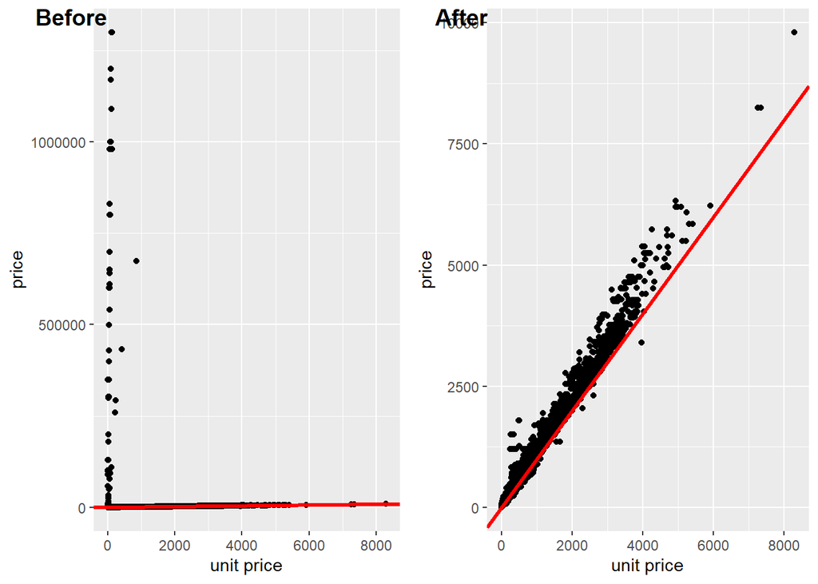

```r
ggarrange(g_before, g_after, labels = c("Before", "After"), ncol = 2, nrow = 1)
```

##### Group 4

```r
line_item_group4 <- line_item_clean %>% filter(k4$cluster == 4)

g_before <- line_item_group4 %>% ggplot(aes(unit_price, price)) +
  geom_point() +
  geom_abline(colour = 'red', size = 1.1, slope = 20000) +
  labs(
    x = "unit price",
    y = "price"
  )
```

```r
line_item_group4 %>% select(unit_price, price) %>% summary()
```

```
##    unit_price       price
##  Min.   : 829   Min.   : 83281154
##  1st Qu.:1139   1st Qu.:115900092
##  Median :1159   Median :115900092
##  Mean   :1133   Mean   :115651092
##  3rd Qu.:1159   3rd Qu.:115900092
##  Max.   :1159   Max.   :115900092
```

```r
line_item_group4 <- line_item_group4 %>% mutate(price = price/100000)
```

```r
g_after <- line_item_group4 %>% ggplot(aes(unit_price, price)) +
  geom_point() +
  geom_abline(colour = 'red', size = 1.1, slope = 20000) +
  labs(
    x = "unit price",
    y = "price"
  )
```

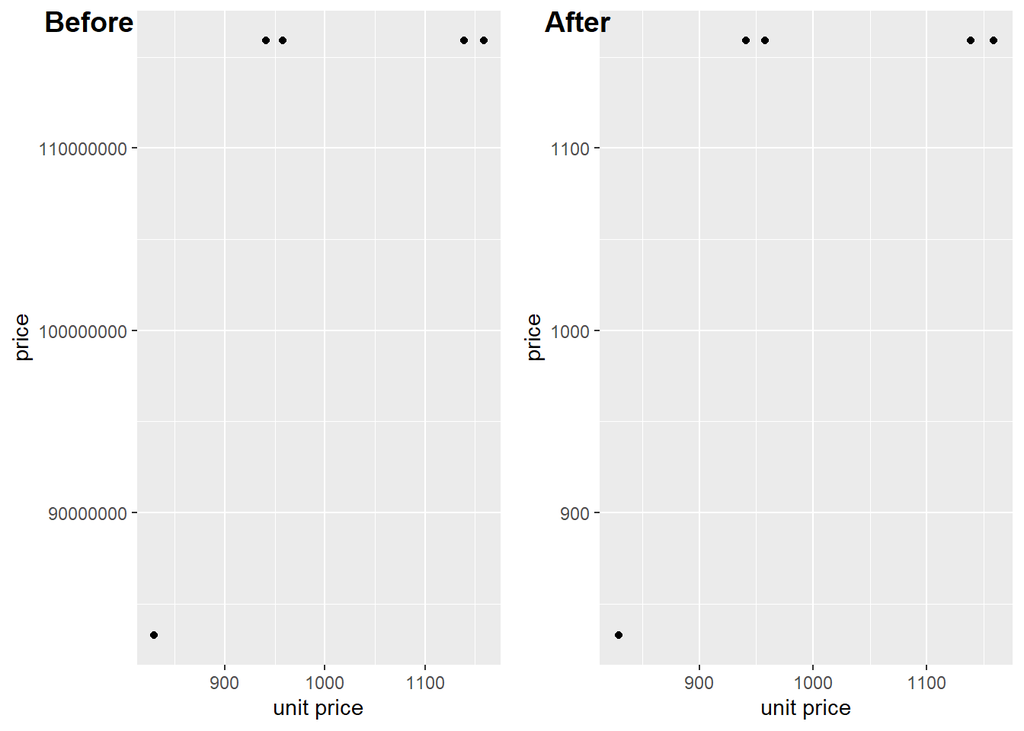

```r
ggarrange(g_before, g_after, labels = c("Before", "After"), ncol = 2, nrow = 1)
```

##### All groups

```r
g_before <- line_item_clean %>% ggplot(aes(unit_price, price)) +
  geom_point() +
  geom_abline(colour = 'red', size = 1.1, slope = 20000) +
  labs(
    x = "unit price",
    y = "price"
  )

line_item_clean <- line_item_group1 %>% bind_rows(line_item_group2) %>% bind_rows(line_item_group3) %>% bind_rows(line_item_group4)

g_after <- line_item_clean %>% ggplot(aes(unit_price, price)) +
  geom_point() +
  geom_abline(colour = 'red', size = 1.1) +
  labs(
    x = "unit price",
    y = "price"
  )

rm(line_item_group1, line_item_group2, line_item_group3, line_item_group4)
```

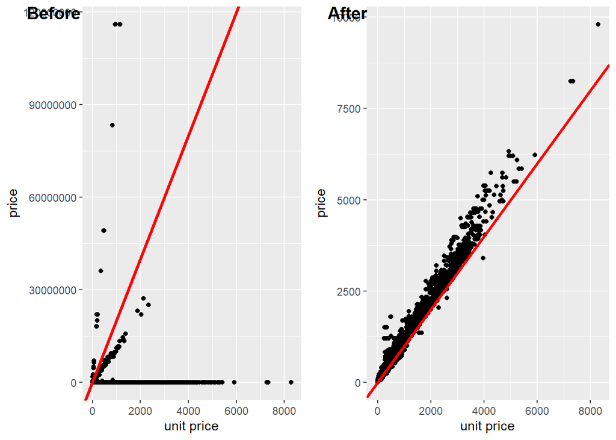

```r
ggarrange(g_before, g_after, labels = c("Before", "After"), ncol = 2, nrow = 1)
```

2. Exclude from *line_items* the rows with differences that you cannot explain.

> **For now, we decided to keep only the values which the absolute difference between unit price and price is smaller than the price multiplied by 75%**

```r
line_item_clean <- line_item_clean %>% filter(abs(unit_price - price) < price*0.75)
```

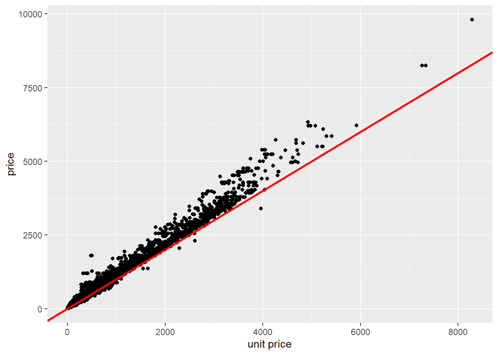

```r
line_item_clean %>% ggplot(aes(unit_price, price)) +
  geom_point() +
  geom_abline(colour = 'red', size = 1.1) +
  labs(
    x = "unit price",
    y = "price"
  )
```

```r
rm(g_after, g_before, k2, k4, k.values, wss_values)
rm(line_item, mydb, orders, products, rs, wss)
```

## Transactional Dataset

```r
# Due to limitation process some sku-items with low frequency (< 3 times bought) were removed
product_freq <- line_item_clean %>% group_by(sku) %>% summarise(quantity = sum(product_quantity)) %>% filter(quantity >= 3)

line_item_clean <- line_item_clean %>% filter(sku %in% product_freq$sku)

transact <- line_item_clean %>% arrange(id_order) %>% mutate(id_order_sku = paste(id_order, sku, sep = ";")) %>% select(id_order_sku) %>% unlist(., use.names=FALSE) %>% paste(., collapse = "\n" )

paste("item_id;trans_id", transact, sep = "\n") %>% write("item_list")
rm(product_freq)
```

```r
transact <- read.transactions("item_list", format = "single", header = TRUE, sep = ";", cols = c("item_id", "trans_id"))
summary(transact)
```

```
## transactions as itemMatrix in sparse format with
##  43572 rows (elements/itemsets/transactions) and
##  3428 columns (items) and a density of 0.00038384
##
## most frequent items:
## APP1184 APP1916 APP0692 APP0921 SAM0068 (Other)
##     931     544     491     383     325   54658
##
## element (itemset/transaction) length distribution:
## sizes
##     1     2     3     4     5     6     7     8     9    10    13
## 34169  6558  1908   600   212    68    26    15    10     5     1
##
##    Min. 1st Qu.  Median    Mean 3rd Qu.    Max.
##    1.00    1.00    1.00    1.32    1.00   13.00
##
## includes extended item information - examples:
##    labels
## 1 8MO0001
## 2 8MO0002
## 3 8MO0003
##
## includes extended transaction information - examples:
##   transactionID
## 1        241423
## 2        242832
## 3        243330
```

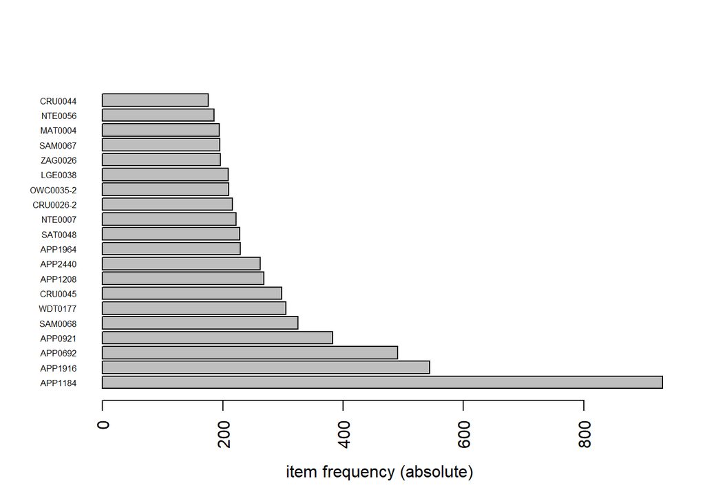

```r
itemFrequencyPlot(transact, type = "absolute", horiz= TRUE, top = 20, support = 0.005, cex.names = .5)
```

## Apriori Algorithm

#### Choice of support and confidence

```r
# Support and confidence values
supportLevels <- c(0.01, 0.005, 0.001, 0.0005, 0.0001)
confidenceLevels <- c(0.9, 0.8, 0.7, 0.6, 0.5, 0.4, 0.3, 0.2, 0.1)

# Empty integers
rules_supA <- integer(length=9)
rules_supB <- integer(length=9)
rules_supC <- integer(length=9)
rules_supD <- integer(length=9)
rules_supE <- integer(length=9)

for (i in 1:length(confidenceLevels)) {
  # Apriori algorithm with a support level of 1%
  rules_supA[i] <- length(apriori(transact, parameter=list(sup=supportLevels[1],
                                  conf=confidenceLevels[i], target="rules",
                                  minlen = 2)))

  # Apriori algorithm with a support level of 0.5%
  rules_supB[i] <- length(apriori(transact, parameter=list(sup=supportLevels[2],
                                  conf=confidenceLevels[i], target="rules",
                                  minlen = 2)))

  # Apriori algorithm with a support level of 0.1%
  rules_supC[i] <- length(apriori(transact, parameter=list(sup=supportLevels[3],
                                  conf=confidenceLevels[i], target="rules",
                                  minlen = 2)))

  # Apriori algorithm with a support level of 0.05%
  rules_supD[i] <- length(apriori(transact, parameter=list(sup=supportLevels[4],
                                  conf=confidenceLevels[i], target="rules",
                                  minlen = 2)))

  # Apriori algorithm with a support level of 0.01%
  rules_supE[i] <- length(apriori(transact, parameter=list(sup=supportLevels[5],
                                  conf=confidenceLevels[i], target="rules",
                                  minlen = 2)))
}
```

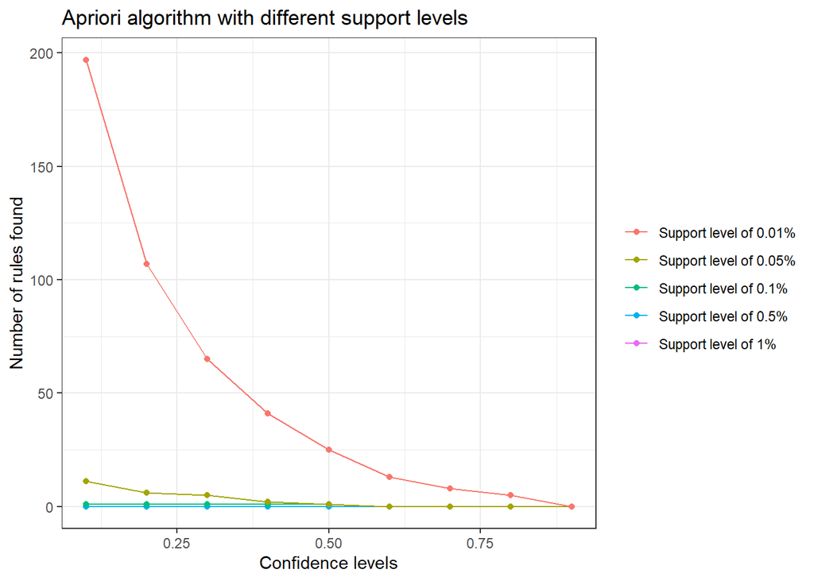

```r
# Data frame
num_rules <- data.frame(rules_supA, rules_supB, rules_supC, rules_supD, rules_supE, confidenceLevels)

# Number of rules found with a support level of 1%, 0.5%, 0.1%, 0.05% and 0.01%
ggplot(data=num_rules, aes(x=confidenceLevels)) +

  # Plot line and points (support level of 1%)
  geom_line(aes(y=rules_supA, colour="Support level of 1%")) +
  geom_point(aes(y=rules_supA, colour="Support level of 1%")) +

  # Plot line and points (support level of 0.5%)
  geom_line(aes(y=rules_supB, colour="Support level of 0.5%")) +
  geom_point(aes(y=rules_supB, colour="Support level of 0.5%")) +

  # Plot line and points (support level of 0.1%)
  geom_line(aes(y=rules_supC, colour="Support level of 0.1%")) +
  geom_point(aes(y=rules_supC, colour="Support level of 0.1%")) +

  # Plot line and points (support level of 0.05%)
  geom_line(aes(y=rules_supD, colour="Support level of 0.05%")) +
  geom_point(aes(y=rules_supD, colour="Support level of 0.05%")) +

  # Plot line and points (support level of 0.01%)
  geom_line(aes(y=rules_supE, colour="Support level of 0.01%")) +
  geom_point(aes(y=rules_supE, colour="Support level of 0.01%")) +

  # Labs and theme
  labs(x="Confidence levels", y="Number of rules found",
       title="Apriori algorithm with different support levels") +
  theme_bw() +
  theme(legend.title=element_blank())
```

```r
rm(i, rules_supA, rules_supB, rules_supC, rules_supD, rules_supE, confidenceLevels, supportLevels, num_rules)
```

#### Decision

We decided to use 0.01% for support and 50% confidence.

```r
trans_rules <- apriori(transact, parameter = list(support = 0.0001, confidence = 0.5, minlen = 2), control = list(verbose=F))
```

```r
summary(trans_rules)
```

```
## set of 25 rules
##
## rule length distribution (lhs + rhs):sizes
##  2  3
## 20  5
##
##    Min. 1st Qu.  Median    Mean 3rd Qu.    Max.
##     2.0     2.0     2.0     2.2     2.0     3.0
##
## summary of quality measures:
##     support           confidence         lift            count
##  Min.   :0.000115   Min.   :0.500   Min.   :  47.9   Min.   : 5.0
##  1st Qu.:0.000115   1st Qu.:0.545   1st Qu.: 217.9   1st Qu.: 5.0
##  Median :0.000138   Median :0.600   Median : 634.1   Median : 6.0
##  Mean   :0.000188   Mean   :0.646   Mean   : 966.1   Mean   : 8.2
##  3rd Qu.:0.000161   3rd Qu.:0.750   3rd Qu.:1650.5   3rd Qu.: 7.0
##  Max.   :0.001079   Max.   :0.875   Max.   :2904.8   Max.   :47.0
##
## mining info:
##      data ntransactions support confidence
##  transact         43572  0.0001        0.5
```

```r
# remove redundant rules
trans_rules <- trans_rules[!is.redundant(trans_rules)]
```

```r
inspectDT(trans_rules)
```

|  | LHS | RHS | support | confidence | lift | count |
| --- | --- | --- | --- | --- | --- | --- |
| [1] | {POL0008} | {POL0010} | 0.000114752593408611 | 0.833333333333333 | 1650.45454545455 | 5 |
| [2] | {OWC0056} | {OWC0054} | 0.000137703112090333 | 0.75 | 837.923076923077 | 6 |
| [3] | {WAC0158} | {WAC0156} | 0.000160653630772055 | 0.875 | 2541.7 | 7 |
| [4] | {PRY0004} | {PRY0003} | 0.000137703112090333 | 0.857142857142857 | 1493.89714285714 | 6 |
| [5] | {NES0009} | {NES0006} | 0.000160653630772055 | 0.777777777777778 | 1093.20430107527 | 7 |
| [6] | {ELG0031} | {ELG0033} | 0.000114752593408611 | 0.555555555555556 | 252.152777777778 | 5 |
| [7] | {APP2114} | {APP1215} | 0.000137703112090333 | 0.5 | 128.152941176471 | 6 |
| [8] | {APP1623} | {APP1215} | 0.000137703112090333 | 0.5 | 128.152941176471 | 6 |
| [9] | {IFX0087} | {IFX0028} | 0.000183604149453778 | 0.666666666666667 | 236.162601626016 | 8 |
| [10] | {ELA0019} | {ELA0016} | 0.000114752593408611 | 0.555555555555556 | 1100.30303030303 | 5 |

[output cut: 15 more lines]

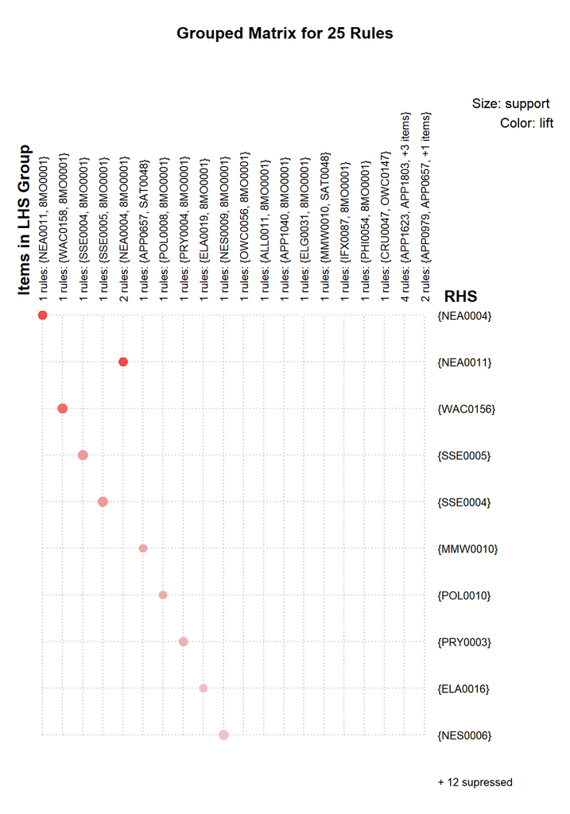

```r
plot(trans_rules, method = "grouped")
```

```r
plot(trans_rules, method = "graph", engine = "htmlwidget")
```

[interactive chart not shown]

| sku | Name | Description | Brand | Category |
| --- | --- | --- | --- | --- |
| ALL0002 | Allocacoc PowerCube Original Regleta White / Blue | Wall socket cube-shaped 5 to 250V electrical outlets | Allocacoc | accessories |
| ALL0011 | Allocacoc PowerCube Original Regleta White / Red | Wall socket cube-shaped 5 to 250V electrical outlets | Allocacoc | accessories |
| APP0657 | AppleCare Protection Plan MacBook / Air / Pro 13 | Apple Care extended warranty Macbook Air / Macbook / Macbook Pro 13-inch. | Apple | extended warranty |
| APP0692 | Apple Lightning Cable Connector to USB 1m White (OEM) | Apple Lightning USB Cable 1 meter to charge and sync iPhone iPad and iPod | Apple | accessories |
| APP0979 | OEM 5W USB Power Adapter iPhone iPod and compatible Apple iPod | OEM USB Power Adapter 5W 1A for iPhone iPad and iPod | Apple | accessories |
| APP1040 | Apple USB Power Adapter-C 29 W | Adapter to any device compatible with USB-C | Apple | accessories |
| APP1215 | Apple Pencil | Pencil Apple iPad Pro. | Apple | accessories |
| APP1565 | Apple Lightning to USB Cable 1m-C | USB-C connection cable 1m Lightning for iPhone iPad and iPod | Apple | accessories |
| APP1623 | Apple iPad Case Smart Keyboard Pro 12.9 | Cover with keyboard shortcuts and Spanish (direct connection) for iPad Pro 12.9 | Apple | accessories |
| APP1803 | Apple Apple Pack 4 Pencil Tips | 4 extra points for Apple Pencil | Apple | accessories |
| APP2114 | Apple iPad Pro 12.9 Wi-Fi + Cellular 256GB Space Gray | New iPad Pro 256GB Wi-Fi | Apple | tablet |
| APP2117 | Apple iPad Pro 10.5 Wi-Fi 256GB Space Gray | MPDY2TY / A | Apple | accessories |
| APP2155 | Smart Apple iPad Keyboard Case Keyboard Pro 10.5 | Cover with keyboard shortcuts and Spanish (direct connection) for iPad Pro 105 | Apple | accessories |
| CRU0047 | Disk 1TB SSD Crucial MX300 | 1050GB SSD Hard Drive SATA 3.0 (6Gb / s) for Mac and PC | Crucial | accessories |
| ELA0016 | elago Lightning Cable 1m Aluminum Space Gray | Charging cable connection and synchronization with Lightning and MFi certified for iPhone iPad and iPod | Elago | accessories |
| ELA0019 | elago Lightning Aluminum Cable 1m Rosa | Charging cable connection and synchronization with Lightning and MFi certified for iPhone iPad and iPod | Elago | accessories |
| ELG0031 | Elgato Eve Wireless Sensor Room Interior | Sensor air quality temperature and humidity for iPhone iPad and iPod Touch. | Elgato | accessories |
| ELG0033 | Elgato Eve Energy Power and Power Wireless Sensor | Plug on-off control sensor and remote power consumption for iPad iPhone iPod Touch and Apple Watch | Elgato | accessories |
| IFX0028 | iFixit battery change Battery Complete kit iPhone 5s | Battery replacement kit with tools for iPhone 5S. | iFixit | accessories |
| IFX0087 | iFixit part adhesive strips Battery iPhone 5s / 5c | adhesive strips replacement battery for iPhone 5s / 5c | iFixit | accessories |
| MMW0010 | My MW Case MacBook Pro 13 (Late 2016) Black | Avoid shock and damage to your MacBook Pro 13-inch end of 2016 thanks to the foam LRPu | My MW | accessories |
| NEA0001 | Urban Netatmo weather station | Wireless weather station for iPhone iPad or iPod Touch. | Netatmo | accessories |
| NEA0004 | Netatmo Pluviometer for weather station | Pluviometer add-on module for weather station. | Netatmo | accessories |
| NEA0011 | Support Netatmo MOODBOARD or Pluviometer | Netatmo support for weather station | Netatmo | accessories |
| NES0006 | Nest Learning Thermostat Intelligent | energy savings and comfort in your home thanks to the smart thermostat Nest | Nest | other |
| NES0009 | Nest Learning Thermostat support | Support 100% compatible with Nest Learning thermostat designed for tables or estanter??as | Nest | accessories |
| NTE0007 | AdaptaDrive NewerTech adapter 2.5 to 3.5 SATA | Adapter HDD / SSD 2.5 SATA 3.5 compatible with Mac Pro. | NewerTech | accessories |
| OWC0054 | Mac OWC Memory 2GB 667MHz DDR2 SO-DIMM | 2GB RAM Mac mini and iMac (2006/07) MacBook Pro (2006/07/08). | OWC | accessories |
| OWC0056 | Mac OWC Memory 1GB 667MHz DDR2 SO-DIMM | 1GB RAM Mac mini and iMac (2006/07) MacBook Pro (2006/07/08). | OWC | accessories |
| OWC0147 | OWC In-line Digital Temperature Sensor Kit iMac 2009 & 2010 | Kit temperature for HDD iMac 21 inches and 27 inches sensor 2009-2010. | OWC | accessories |
| PHI0054 | Philips Hue smart switch Tap Wireless Controller | intelligent wireless control switch with four scenes | Philips | accessories |
| PHI0070 | Philips Hue Motion Motion Sensor | System motion sensor for Philips Hue | Philips | accessories |
| POL0008 | ZIP Polaroid Mobile Printer Bluetooth Black | portable printer with Bluetooth and NFC Micro-USB charging port connection and print 10 sheets for iPhone iPad and iPod | Polaroid | printer |
| POL0010 | Polaroid ZINK 50 Pack 50 sheets Print | Pack 50 sheets of print material resistant adhesive and back to Polaroid ZIP | Polaroid | accessories |
| PRY0003 | Zink Prynt Sticker Pack 40 sheets Print | Pack of 40 sheets printing adhesive back for printer Prynt Case | Prynt | accessories |
| PRY0004 | Prynt Graphite iPhone Mobile Printer Pocket | Portable Printer for iPhone | Prynt | printer |
| SAT0048 | Satechi Hub Multiport USB-C 4K HDMI Space Gray | Aluminum adapter with USB Type-C HDMI 4K three ports USB Type-A Ethernet input and SD card reader micro SD for Mac and PC. | Satechi | accessories |
| SSE0004 | Sen.se ThermoPeanut Green Smart Wireless Thermometer | Bluetooth thermometer measures the temperature outside and inside with alerts for iPhone app and iPad or iPod | Sen.se | other |
| SSE0005 | Sen.se ThermoPeanut Intelligent wireless thermometer Blue | Bluetooth thermometer measures the temperature outside and inside with alerts for iPhone app and iPad or iPod | Sen.se | other |
| WAC0156 | Wacom Cintiq Interactive Pen Display 27QHD Mac and PC | professional graphics tablet with widescreen 16: 9 remote control and Pro Pen for Mac and PC. | Wacom | tablet |
| WAC0158 | Wacom Cintiq Ergo Stand 27QHD | Professional support for Wacom Cintiq 27QHD. | Wacom | accessories |